# **Informational Interview with Dr. Claude Ngwayu Nkfusai.**

### **Introduction.**

I was able to do an informational interview with Dr. Claude Ngwayu who is currently working as a surveillance epidemiologist at Clinton Health Access Initiative (CHAI), based in Cameroon office. And he also said it was nice to have this interview since researchers need to share their knowledge and experiences. This is always like a responsibility to every researcher.

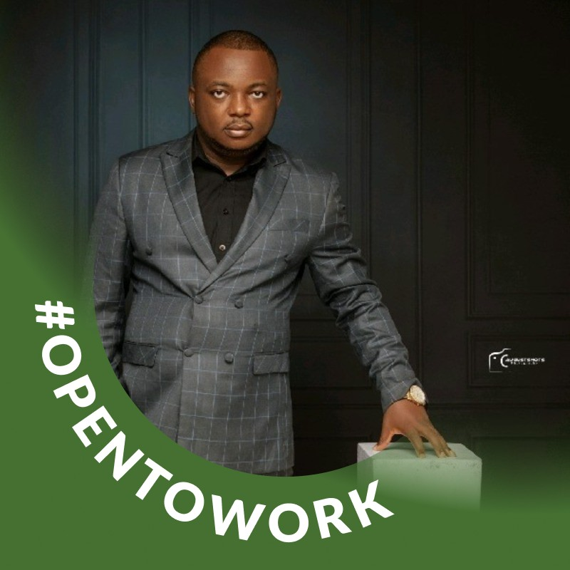

Dr.Claude Ngwayu

### **Background.**

**Can you share with me your career path to where you are now?**

I have a bachelor of science degree in microbiology, and I went on to complete a master’s in epidemiology control of infectious diseases. I am currently working on my PhD thesis at the School of Nursing and Public health at University of Kwazulu Nathal, and that’s my academic background.

In professional background, When I was at school, I expanded more in hygiene stuffs and from 2012-2016 I did several projects over that period. And in 2022-2023 I worked as Knowledge management coordinator at Malaria Consortium, and was also a part-time Lecturer at St. Louis Higher Institute of Medical Studies from 2020-2023. Currently am working with The Global South Health Research and Services (GSHS) as Senior monitoring and evaluation specialist from 2021- to date, but also working at Clinton Health Access Initiative as Surveillance Epidemiologist Associate from 2023- present.

### **General questions.**

**What do you actually do in your career?**

With 13 years of experience in infectious disease epidemiology and public health, and currently working as a surveillance epidemiologist at CHAI. In this role, I manage and coordinate malaria surveillance activities in the country,supporting the development and review of national guidelines and training materials for the malaria program team, and provide analytical support to CHAI’s regional and country teams. I also handle datasets for various projects related to malaria epidemiology, intervention targeting and surveillance.

I am also a researcher and currently having over 75 publications. My most recent work was published in the year 2025 at VeriXiv titled “Enhancing Malaria Surveillance in Cameroon: Findings and Recommendations from a cross-sectional Nationwide qualitative study”.

I develop tools that will be used in data collection and in data analysis plan at GSHS.

**What does a typical day in your role look like?**

My days are always busy and time-driven, it starts in the morning at 4 am by checking the calender to review the day’s schedule such as upcoming meetings and any other day activities. After that its when I do the works for the GSHS, writing my thesis or the manuscripts. Then at 8 o’clock it’s when I leave for work at CHAI for the normal day timetable to 4:30pm, then goes for rest.

**What skills or experiences are crucial for someone in your position?**

For CHAI does capacity building but for enrollment you need to be an epidemiologist, to be able to prepare good power points that present well your findings in a way that it can be understood well. Also knowing the data collection techniques and do the analysis using different software, be able to write the manuscripts, and also you need to know how to work with the DHIS data.

**What are the most rewarding and challenging aspects of your job?**

We even had to train people who are working at the field, but it was also not helping since people tend to change their jobs, you train someone today and tomorrow he is not there, someone else comes and does the same mistakes. So scenarios like those becomes very challenging.

**How do you see the field evolving in the next few years? Your insight and perspective on future trends, developments, and changes in your field of expertise. Since we are now focused on geo-spatial analysis and predictive modeling to better target interventions and with this increasing availability of high-resolution spatial and climatic data**

With the presence of Artificial Intelligence (AI) I see the field turning to be more easy to many staffs, for it will reach a time that these AI are going to take over a big part of the work, you will only need to upload the data sets and it does the whole analysis and gives you the best output with no errors, instead of going around some processes running the codes, get the outputs and prepare the reports. Also in future we could have the data quality check in the systems like kobotool box and that would bring to even 99% of data accuracy. So there is a lot to come in this area which will be more helpful.

### **Advice and Insight.**

**What advice would you give to someone looking to break into this field?**

Also you need to be someone who likes reading and I recommend to read the hard copies since I also use those mostly. So if you want maybe to know about something either about surveillance then take the readings about the topic, skim them and prioritize, and then dig into it. And that’s the best way of getting to learn new things.

### **Closing the interview.**

We finally reached to the end time, and I thanked him for his time and cooperation during the whole interview process, it was interesting to hear and get some insights from someone in the field of malaria epidemiology.